# Feather River Mini Snorkel Data - Database Comparison

## Comparison Highlights

- The `minisnorkdb3` that Ryon has recently provided seems to be more complete than the `MiniSnorkDBT` database.
- There are some differences between the two datasets, major differences include:
  - In some cases, the `dist_to_bottom` variable is an order of magnitude different between the two datasets, with the older `MiniSnorkDBT` being larger (example: 5.0 vs. 0.5)
  - In some cases, the location names and coordinates are different between the two datasets
- The `minisnorkdb3` database is the only one that contains 2002 data
- There are two additional rows in 2001 for the `minisnorkdb3` database on 5/21/2001 that account for an additional 152 fish counts

## Description

Two databases were provided containing data for 2001 and 2002 with some overlap. This markdown will compare the databases and explore differences.

**Timeframe:** March 2001 - August 2001 (`MiniSnorkDBT`) & March 2001 - August 2002 (`minisnorkdb3`)

**Completeness of Record throughout timeframe:** fairly complete

**Sampling Location:** Feather River

**Data Contact:** Ryon Kurth

## Source Database pull

- Database 1: `MiniSnorkelDTB.mdb`
- Database 2: `minisnorkdb3.mdb`

### Data transformations

All of the substrate and cover lookups are not true look ups. Substrate and cover column indicate a percentage of cover or substrate of each type. I updated the column names to reflect this and utilized the lookup tables to understand which substrate or cover type each column was referring to.

Columns removed:

- SpecAge removed - just a combination of species and age
- i_cov_sum - removed because sum of other columns
- o_cov_sum - removed because sum of other columns
- sub_sum - removed because sum of other columns
- start_time - just a date that seemed wrong
- end_time - also just a date that seemed wrong
- crew - specific crew names do not need to be present on public EDI dataset

The two databases have the same format and therefore the same script can be used to combine tables into one (`joined_fish_obs` or `joined_fish_obs_2002`) dataset for each of the databases.

```r
# MiniSnorkDBT

# For different database tables, combine here
# 2001 data:
joined_fish_obs <- microhabitat |>
  left_join(fish_data, by = c("TCode" = "TCode", "PDatID" = "PDatID")) |>
  left_join(species_code_lookup, by = c("Species" = "SpeciesCodeID")) |> # all codes are in the lookup
  select(-c(SpeciesCode, Species)) |>
  rename(species = Species.y,
         percent_fine_substrate = Sub1,
         percent_sand_substrate = Sub2,
         percent_small_gravel_substrate = Sub3,
         percent_large_gravel_substrate = Sub4,
         percent_cobble_substrate = Sub5,
         percent_boulder_substrate = Sub6,
         percent_no_cover_inchannel = IcovA,
         percent_small_woody_cover_inchannel = IcovB,
         percent_large_woody_cover_inchannel = IcovC,
         percent_submerged_aquatic_veg_inchannel = IcovE,
         percent_undercut_bank = IcovF,
         percent_no_cover_overhead = Ocov0,
         percent_cover_half_meter_overhead = Ocov1,
         percent_cover_more_than_half_meter_overhead = Ocov2)|>
  # Clean in separate file
  left_join(location_table, by = c("PDatID" = "PhysDataTblID")) |>
  left_join(weather_code_lookup, by = c("Weather" = "WeatherCodeLookUpID")) |> # all codes are in the lookup
  select(-WeatherCode, -Weather) |>
  rename(weather = Weather.y) |>
  # note that there are 0 channel types which do not map to the lookup
  left_join(channel_lookup, by = c("ChannelType" = "ChannelTypeCode")) |>
  select(-ChannelType, -ChannelTypeCodeID) |>
  rename(channel_type = ChannelType.y) |>
  janitor::clean_names() |>
  # fixes issues with the codes so the CGU lookup will work
  mutate(cgu = tolower(cgu),
         cgu = case_when(cgu == "rm`" ~ "rm",
                         cgu == "gm." ~ "gm",
                         cgu == "" ~ NA,
                         T ~ cgu)) |>
  left_join(cgu_code_lookup |> mutate(CGUCode = tolower(CGUCode)), by = c("cgu" = "CGUCode")) |>
  select(-cgu, -CGUCodeID, -sub_sum, -i_cov_sum, -o_cov_sum, -start_time, -end_time, -crew) |>
  rename(channel_geomorphic_unit = CGU) |> glimpse()
```

```
## Rows: 5,029
## Columns: 39
## $ micro_hab_data_tbl_id                       <int> 18, 18, 18, 19, 20, 21, 22…
## $ p_dat_id                                    <dbl> 11, 11, 11, 11, 11, 11, 11…
## $ t_code                                      <dbl> 0.1, 0.1, 0.1, 0.2, 0.3, 0…
## $ depth                                       <int> 17, 17, 17, 19, 11, 12, 11…
## $ velocity                                    <dbl> 0.22, 0.22, 0.22, 0.35, 1.…
## $ percent_fine_substrate                      <int> 0, 0, 0, 0, 0, 0, 0, 0, 0,…
## $ percent_sand_substrate                      <int> 40, 40, 40, 50, 25, 0, 70,…
## $ percent_small_gravel_substrate              <int> 20, 20, 20, 40, 75, 80, 30…
## $ percent_large_gravel_substrate              <int> 30, 30, 30, 10, 0, 20, 0, …
## $ percent_cobble_substrate                    <int> 10, 10, 10, 0, 0, 0, 0, 0,…
## $ percent_boulder_substrate                   <int> 0, 0, 0, 0, 0, 0, 0, 0, 0,…
## $ percent_no_cover_inchannel                  <int> 75, 75, 75, 100, 100, 100,…
## $ percent_small_woody_cover_inchannel         <int> 15, 15, 15, 0, 0, 0, 20, 0…
```

[output cut: 26 more lines]

```r
# HOW many have fish
# joined_fish_obs |> filter(count >= 0) |> nrow()
```

```r
# minisnorkdb3

# For different database tables, combine here
# 2001/2002 data:
joined_fish_obs_2002 <- microhabitat_2002 |>
  left_join(fish_data_2002, by = c("TCode" = "TCode", "PDatID" = "PDatID")) |>
  left_join(species_code_lookup_2002, by = c("Species" = "SpeciesCodeID")) |> # all codes are in the lookup
  select(-c(SpeciesCode, Species)) |>
  rename(species = Species.y,
         percent_fine_substrate = Sub1,
         percent_sand_substrate = Sub2,
         percent_small_gravel_substrate = Sub3,
         percent_large_gravel_substrate = Sub4,
         percent_cobble_substrate = Sub5,
         percent_boulder_substrate = Sub6,
         percent_no_cover_inchannel = IcovA,
         percent_small_woody_cover_inchannel = IcovB,
         percent_large_woody_cover_inchannel = IcovC,
         percent_submerged_aquatic_veg_inchannel = IcovE,
         percent_undercut_bank = IcovF,
         percent_no_cover_overhead = Ocov0,
         percent_cover_half_meter_overhead = Ocov1,
         percent_cover_more_than_half_meter_overhead = Ocov2)|>
  # Clean in separate file
  left_join(location_table_2002, by = c("PDatID" = "PhysDataTblID")) |>
  left_join(weather_code_lookup_2002, by = c("Weather" = "WeatherCodeLookUpID")) |> # all codes are in the lookup
  select(-WeatherCode, -Weather) |>
  rename(weather = Weather.y) |>
  # note that there are 0 channel types which do not map to the lookup
  left_join(channel_lookup_2002, by = c("ChannelType" = "ChannelTypeCode")) |>
  select(-ChannelType, -ChannelTypeCodeID) |>
  rename(channel_type = ChannelType.y) |>
  janitor::clean_names() |>
  # fixes issues with the codes so the CGU lookup will work
  mutate(cgu = tolower(cgu),
         cgu = case_when(cgu == "rm`" ~ "rm",
                         cgu == "gm." ~ "gm",
                         cgu == "" ~ NA,
                         T ~ cgu)) |>
  left_join(cgu_code_lookup_2002 |> mutate(CGUCode = tolower(CGUCode)), by = c("cgu" = "CGUCode")) |>
  select(-cgu, -CGUCodeID, -sub_sum, -i_cov_sum, -o_cov_sum, -start_time, -end_time, -crew) |>
  rename(channel_geomorphic_unit = CGU) |>
  filter(!is.na(date)) |>
  write_csv('2002_fish_obs_tmp.csv') # annoying workaround to remove labeled date column

joined_fish_obs_2002 <- read_csv('2002_fish_obs_tmp.csv')  |> glimpse()
```

```
##
## Rows: 9,827
## Columns: 52
## $ micro_hab_data_tbl_id                       <dbl> 18, 18, 18, 19, 20, 21, 22…
## $ p_dat_id                                    <dbl> 11, 11, 11, 11, 11, 11, 11…
## $ t_code                                      <dbl> 0.1, 0.1, 0.1, 0.2, 0.3, 0…
## $ depth                                       <dbl> 17, 17, 17, 19, 11, 12, 11…
## $ velocity                                    <dbl> 0.22, 0.22, 0.22, 0.35, 1.…
## $ percent_fine_substrate                      <dbl> 0, 0, 0, 0, 0, 0, 0, 0, 0,…
## $ percent_sand_substrate                      <dbl> 40, 40, 40, 50, 25, 0, 70,…
## $ percent_small_gravel_substrate              <dbl> 20, 20, 20, 40, 75, 80, 30…
## $ percent_large_gravel_substrate              <dbl> 30, 30, 30, 10, 0, 20, 0, …
## $ percent_cobble_substrate                    <dbl> 10, 10, 10, 0, 0, 0, 0, 0,…
## $ percent_boulder_substrate                   <dbl> 0, 0, 0, 0, 0, 0, 0, 0, 0,…
## $ percent_no_cover_inchannel                  <dbl> 75, 75, 75, 100, 100, 100,…
```

[output cut: 40 more lines]

### Checking Overlap Between Two Databases

- 2001 dataset (`MiniSnorkelDTB.mdb`) goes from 2001-03-13 to 2001-08-23
- new 2001/2002 (``minisnorkdb3.mdb`) dataset goes from 2001-03-13 to 2002-08-20

The following figure shows that the `minisnorkdb3` database is the only database that includes 2002 data.

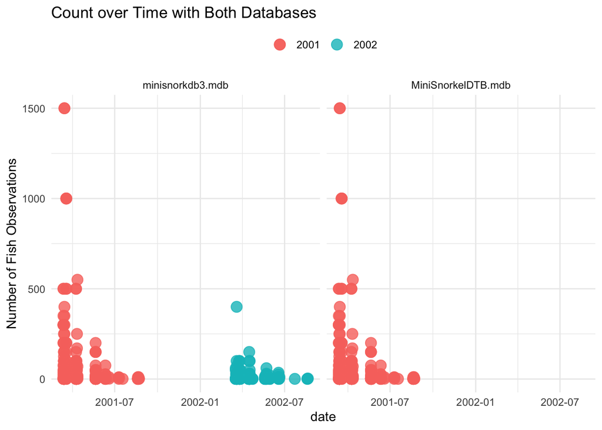

```r
ggplot(data = joined_fish_obs_2002 |> mutate(database = "minisnorkdb3.mdb")) +
  geom_point(aes(x = date, y = count, color = as.factor(year(date))), size = 4, alpha = .8) +
  geom_point(data = joined_fish_obs |> mutate(database = "MiniSnorkelDTB.mdb"),
             aes(x=date, y = count, color = as.factor(year(date))), size = 4, alpha = .8)+
  theme_minimal()+
  labs(title = "Count over Time with Both Databases",
       y = "Number of Fish Observations") +
    theme(legend.position = "top", legend.title = element_blank()) +
  facet_grid(~ database)
```

### View differences between databases

First, let’s filter the minisnorkdb3 database to the time period that exists in the MiniSnorkDb to see if there are differences in the 2001 data.

```r
only_2001_data <- joined_fish_obs_2002 |>
  filter(date <= max(joined_fish_obs$date))
```

- Number of rows in `minisnorkdb3` (filtered to 2001 data): 5031
- Number of rows in `MiniSnorkDBT`: 5029

Based off the number of rows in each of the datasets, there are two additional rows in the `minisnorkdb3` 2001 data.

Let’s now look at each date to see if that is where the inconsistencies are found.

```r
joined_fish_obs |>
  group_by(date) |>
  summarise(n_obs_MiniSnorkelDTB = n(),
            sum_count_MiniSnorkelDTB = sum(count, na.rm = TRUE)) |>
  full_join(
    only_2001_data |>
      group_by(date) |>
      summarise(n_obs_minisnorkdb3 = n(),
                sum_count_minisnorkdb3 = sum(count, na.rm = TRUE))
  ) |>
  mutate(same_value_obs = ifelse(n_obs_MiniSnorkelDTB == n_obs_minisnorkdb3, "TRUE", "FALSE"), # The only date with differences is 5/21/2001
         same_value_count = ifelse(sum_count_minisnorkdb3 == sum_count_MiniSnorkelDTB, "TRUE", "FALSE")) |>
  filter(same_value_obs == FALSE | same_value_count == FALSE) |>
  knitr::kable()
## Joining with `by = join_by(date)`
```

| date | n_obs_MiniSnorkelDTB | sum_count_MiniSnorkelDTB | n_obs_minisnorkdb3 | sum_count_minisnorkdb3 | same_value_obs | same_value_count |
| --- | --- | --- | --- | --- | --- | --- |
| 2001-05-21 | 239 | 1070 | 241 | 1222 | FALSE | FALSE |

Based on the information in the table above, 5/21/2001 is where there two additional rows come from.

Aside from the inconsistency on 5/21/2001, are the data the same? Doing an `anti_join` allows us to see which rows are different between the two datasets.

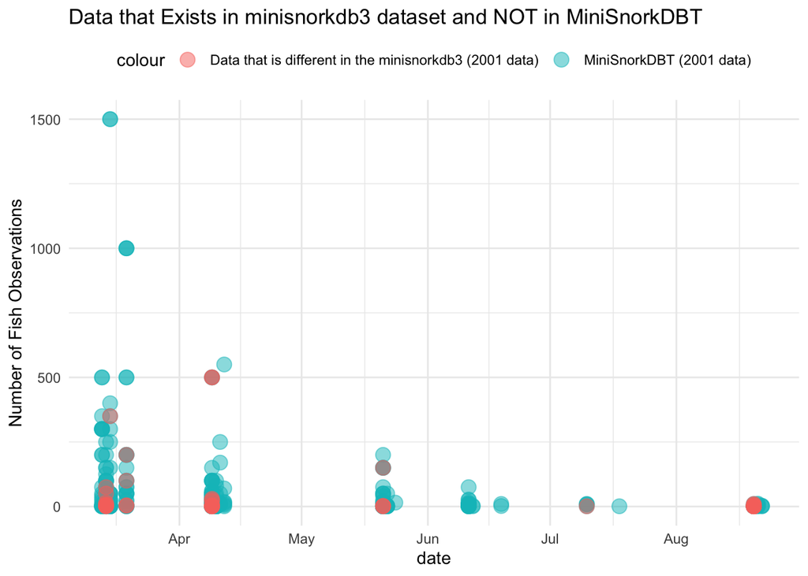

```r
anti_join_2001_data <- only_2001_data |>
  select(colnames(joined_fish_obs)) |>
  anti_join(joined_fish_obs)
## Joining with `by = join_by(micro_hab_data_tbl_id, p_dat_id, t_code, depth,
## velocity, percent_fine_substrate, percent_sand_substrate,
## percent_small_gravel_substrate, percent_large_gravel_substrate,
## percent_cobble_substrate, percent_boulder_substrate,
## percent_no_cover_inchannel, percent_small_woody_cover_inchannel,
## percent_large_woody_cover_inchannel, percent_submerged_aquatic_veg_inchannel,
## percent_undercut_bank, percent_no_cover_overhead,
## percent_cover_half_meter_overhead, percent_cover_more_than_half_meter_overhead,
## sur_turb, fish_data_id, count, fl_mm, dist_to_bottom, focal_velocity, species,
## location, date, water_temp, river_mile, flow, number_of_divers, reach_length,
## reach_width, channel_width, gps_coordinate, weather, channel_type,
## channel_geomorphic_unit)`

ggplot() +
  geom_point(data = joined_fish_obs, aes(x=date, y = count, color = "MiniSnorkDBT (2001 data)"), size = 4, alpha = .5) +
  geom_point(data = anti_join_2001_data, aes(x = date, y = count, color = 'Data that is different in the minisnorkdb3 (2001 data)'), alpha = 0.5, size = 4) +
  theme_minimal()+
  labs(title = "Data that Exists in minisnorkdb3 dataset and NOT in MiniSnorkDBT",
       y = "Number of Fish Observations") +
  theme(legend.position = "top")
```

There are 60 rows in the `anti_join` implying that at least one value is inconsistent for each of those rows. The figure above shows a visual of the data that is different.

The main differences are within the `dist_to_bottom` variable where the new database has values that are an order of magnitude lower (0.5 vs 5) than the older 2001 database. Other minor differences are in the location coordinates/names. The table below highlights the major differences between the two databases.

```r
# The main differences are within the `dist_to_bottom` variable where the new database has values that are an order
# of magnitude lower (0.5 vs 5) than the older 2001 database

library(compareDF)

new_data <- only_2001_data |>
  select(colnames(joined_fish_obs)) |>
  mutate(database = "minisnorkdb3") |>
  filter(micro_hab_data_tbl_id %in% anti_join_2001_data$micro_hab_data_tbl_id)

old_data <- joined_fish_obs |>
  mutate(database = "MiniSnorkDTB") |>
  filter(micro_hab_data_tbl_id %in% anti_join_2001_data$micro_hab_data_tbl_id)

comp <- compare_df(new_data, old_data, group_col = c('micro_hab_data_tbl_id', 'date', 'database'), keep_unchanged_cols = FALSE)
## Found Date columns! Will be casted to character for comparison!
## Found Date columns! Will be casted to character for comparison!
## Grouping columns
## Creating comparison table...

create_output_table(comp)
## Truncating HTML diff table to ${limit_html} rows...
## Creating HTML table for first ${limit_html} rows
```

| grp | chng_type | micro_hab_data_tbl_id | p_dat_id | t_code | depth | velocity | percent_fine_substrate | percent_sand_substrate | percent_small_gravel_substrate | percent_large_gravel_substrate | percent_cobble_substrate | percent_boulder_substrate | percent_no_cover_inchannel | percent_small_woody_cover_inchannel | percent_large_woody_cover_inchannel | percent_submerged_aquatic_veg_inchannel | percent_undercut_bank | percent_no_cover_overhead | percent_cover_half_meter_overhead | percent_cover_more_than_half_meter_overhead | sur_turb | fish_data_id | count | fl_mm | dist_to_bottom | focal_velocity | species | location | date | … |
| --- | --- | --- | --- | --- | --- | --- | --- | --- | --- | --- | --- | --- | --- | --- | --- | --- | --- | --- | --- | --- | --- | --- | --- | --- | --- | --- | --- | --- | --- | --- |
| 1 | - | 25 | 11 | 3.4 | 9 | 1.97 | 0 | 0 | 70 | 30 | 0 | 0 | 100 | 0 | 0 | 0 | 0 | 100 | 0 | 0 | 10 | 11 | 1 | 40 | 5 | 0.50999999 | Chinook salmon | hatchery ditch | 2001-03-14 | … |
| 2 | + | 25 | 11 | 3.4 | 9 | 1.97 | 0 | 0 | 70 | 30 | 0 | 0 | 100 | 0 | 0 | 0 | 0 | 100 | 0 | 0 | 10 | 11 | 1 | 40 | 0.5 | 0.50999999 | Chinook salmon | hatchery ditch | 2001-03-14 | … |
| 3 | - | 29 | 11 | 6.4 | 37 | 0.91 | 0 | 65 | 25 | 10 | 0 | 0 | 100 | 0 | 0 | 0 | 0 | 100 | 0 | 0 | 30 | 12 | 1 | 25 | 1 | 0.63999999 | Steelhead trout (wild) | hatchery ditch | 2001-03-14 | … |
| 3 | - | 29 | 11 | 6.4 | 37 | 0.91 | 0 | 65 | 25 | 10 | 0 | 0 | 100 | 0 | 0 | 0 | 0 | 100 | 0 | 0 | 30 | 13 | 50 | 40 | 5 | 1.08 | Chinook salmon | hatchery ditch | 2001-03-14 | … |
| 3 | - | 29 | 11 | 6.4 | 37 | 0.91 | 0 | 65 | 25 | 10 | 0 | 0 | 100 | 0 | 0 | 0 | 0 | 100 | 0 | 0 | 30 | 14 | 6 | 75 | 5 | 0.80000001 | Chinook salmon | hatchery ditch | 2001-03-14 | … |
| 3 | - | 29 | 11 | 6.4 | 37 | 0.91 | 0 | 65 | 25 | 10 | 0 | 0 | 100 | 0 | 0 | 0 | 0 | 100 | 0 | 0 | 30 | 26 | 10 | 40 | 1.5 | 0.94 | Chinook salmon | hatchery ditch | 2001-03-14 | … |
| 3 | - | 29 | 11 | 6.4 | 37 | 0.91 | 0 | 65 | 25 | 10 | 0 | 0 | 100 | 0 | 0 | 0 | 0 | 100 | 0 | 0 | 30 | 27 | 20 | 35 | 1.5 | 0.94 | Chinook salmon | hatchery ditch | 2001-03-14 | … |
| 4 | + | 29 | 11 | 6.4 | 37 | 0.91 | 0 | 65 | 25 | 10 | 0 | 0 | 100 | 0 | 0 | 0 | 0 | 100 | 0 | 0 | 30 | 12 | 1 | 25 | 0.1 | 0.63999999 | Steelhead trout (wild) | hatchery ditch | 2001-03-14 | … |
| 4 | + | 29 | 11 | 6.4 | 37 | 0.91 | 0 | 65 | 25 | 10 | 0 | 0 | 100 | 0 | 0 | 0 | 0 | 100 | 0 | 0 | 30 | 13 | 50 | 40 | 0.5 | 1.08 | Chinook salmon | hatchery ditch | 2001-03-14 | … |
| 4 | + | 29 | 11 | 6.4 | 37 | 0.91 | 0 | 65 | 25 | 10 | 0 | 0 | 100 | 0 | 0 | 0 | 0 | 100 | 0 | 0 | 30 | 14 | 6 | 75 | 0.5 | 0.80000001 | Chinook salmon | hatchery ditch | 2001-03-14 | … |
| 4 | + | 29 | 11 | 6.4 | 37 | 0.91 | 0 | 65 | 25 | 10 | 0 | 0 | 100 | 0 | 0 | 0 | 0 | 100 | 0 | 0 | 30 | 26 | 10 | 40 | 1.5 | 0.94 | Chinook salmon | hatchery ditch | 2001-03-14 | … |
| 4 | + | 29 | 11 | 6.4 | 37 | 0.91 | 0 | 65 | 25 | 10 | 0 | 0 | 100 | 0 | 0 | 0 | 0 | 100 | 0 | 0 | 30 | 27 | 20 | 35 | 1.5 | 0.94 | Chinook salmon | hatchery ditch | 2001-03-14 | … |
| 5 | - | 33 | 11 | 9.4 | 15 | 2.17 | 0 | 10 | 90 | 0 | 0 | 0 | 100 | 0 | 0 | 0 | 0 | 100 | 0 | 0 | 20 | 15 | 3 | 25 | 1 | 0.44 | Steelhead trout (wild) | hatchery ditch | 2001-03-14 | … |
| 6 | + | 33 | 11 | 9.4 | 15 | 2.17 | 0 | 10 | 90 | 0 | 0 | 0 | 100 | 0 | 0 | 0 | 0 | 100 | 0 | 0 | 20 | 15 | 3 | 25 | 0.1 | 0.44 | Steelhead trout (wild) | hatchery ditch | 2001-03-14 | … |
| 7 | - | 37 | 11 | 12.4 | 19 | 1.01 | 0 | 40 | 60 | 0 | 0 | 0 | 100 | 0 | 0 | 0 | 0 | 100 | 0 | 0 | 30 | 16 | 8 | 50 | 1 | 0.18000001 | Chinook salmon | hatchery ditch | 2001-03-14 | … |
| 7 | - | 37 | 11 | 12.4 | 19 | 1.01 | 0 | 40 | 60 | 0 | 0 | 0 | 100 | 0 | 0 | 0 | 0 | 100 | 0 | 0 | 30 | 17 | 15 | 40 | 1 | 0.5 | Chinook salmon | hatchery ditch | 2001-03-14 | … |
| 7 | - | 37 | 11 | 12.4 | 19 | 1.01 | 0 | 40 | 60 | 0 | 0 | 0 | 100 | 0 | 0 | 0 | 0 | 100 | 0 | 0 | 30 | 18 | 2 | 25 | 1 | 0.5 | Steelhead trout (wild) | hatchery ditch | 2001-03-14 | … |
| 8 | + | 37 | 11 | 12.4 | 19 | 1.01 | 0 | 40 | 60 | 0 | 0 | 0 | 100 | 0 | 0 | 0 | 0 | 100 | 0 | 0 | 30 | 16 | 8 | 50 | 0.1 | 0.18000001 | Chinook salmon | hatchery ditch | 2001-03-14 | … |
| 8 | + | 37 | 11 | 12.4 | 19 | 1.01 | 0 | 40 | 60 | 0 | 0 | 0 | 100 | 0 | 0 | 0 | 0 | 100 | 0 | 0 | 30 | 17 | 15 | 40 | 0.1 | 0.5 | Chinook salmon | hatchery ditch | 2001-03-14 | … |
| 8 | + | 37 | 11 | 12.4 | 19 | 1.01 | 0 | 40 | 60 | 0 | 0 | 0 | 100 | 0 | 0 | 0 | 0 | 100 | 0 | 0 | 30 | 18 | 2 | 25 | 0.1 | 0.5 | Steelhead trout (wild) | hatchery ditch | 2001-03-14 | … |
| 9 | - | 45 | 11 | 18.4 | 23 | 0.78 | 0 | 15 | 70 | 15 | 0 | 0 | 100 | 0 | 0 | 0 | 0 | 100 | 0 | 0 | 10 | 19 | 5 | 45 | 1 | 0.5 | Chinook salmon | hatchery ditch | 2001-03-14 | … |
| 10 | + | 45 | 11 | 18.4 | 23 | 0.78 | 0 | 15 | 70 | 15 | 0 | 0 | 100 | 0 | 0 | 0 | 0 | 100 | 0 | 0 | 10 | 19 | 5 | 45 | 0.1 | 0.5 | Chinook salmon | hatchery ditch | 2001-03-14 | … |
| 11 | - | 53 | 11 | 24.4 | 13 | 1.88 | 0 | 0 | 85 | 15 | 0 | 0 | 90 | 0 | 0 | 10 | 0 | 100 | 0 | 0 | 10 | 20 | 75 | 45 | 5 | 0.37 | Chinook salmon | hatchery ditch | 2001-03-14 | … |
| 11 | - | 53 | 11 | 24.4 | 13 | 1.88 | 0 | 0 | 85 | 15 | 0 | 0 | 90 | 0 | 0 | 10 | 0 | 100 | 0 | 0 | 10 | 40 | 1 | 30 | 1 | 1.05 | Chinook salmon | hatchery ditch | 2001-03-14 | … |
| 11 | - | 53 | 11 | 24.4 | 13 | 1.88 | 0 | 0 | 85 | 15 | 0 | 0 | 90 | 0 | 0 | 10 | 0 | 100 | 0 | 0 | 10 | 41 | 1 | 35 | 1 | 0.98000002 | Chinook salmon | hatchery ditch | 2001-03-14 | … |
| 12 | + | 53 | 11 | 24.4 | 13 | 1.88 | 0 | 0 | 85 | 15 | 0 | 0 | 90 | 0 | 0 | 10 | 0 | 100 | 0 | 0 | 10 | 20 | 75 | 45 | 0.5 | 0.37 | Chinook salmon | hatchery ditch | 2001-03-14 | … |
| 12 | + | 53 | 11 | 24.4 | 13 | 1.88 | 0 | 0 | 85 | 15 | 0 | 0 | 90 | 0 | 0 | 10 | 0 | 100 | 0 | 0 | 10 | 40 | 1 | 30 | 1 | 1.05 | Chinook salmon | hatchery ditch | 2001-03-14 | … |
| 12 | + | 53 | 11 | 24.4 | 13 | 1.88 | 0 | 0 | 85 | 15 | 0 | 0 | 90 | 0 | 0 | 10 | 0 | 100 | 0 | 0 | 10 | 41 | 1 | 35 | 1 | 0.98000002 | Chinook salmon | hatchery ditch | 2001-03-14 | … |
| 13 | - | 74 | 12 | 12.4 | 50 | 0 | 0 | 20 | 70 | 10 | 0 | 0 | 0 | 70 | 0 | 30 | 0 | 30 | 0 | 70 | 0 | 54 | 350 | 40 | 5 | 0.2 | Chinook salmon | Hour Bar | 2001-03-15 | … |
| 14 | + | 74 | 12 | 12.4 | 50 | 0 | 0 | 20 | 70 | 10 | 0 | 0 | 0 | 70 | 0 | 30 | 0 | 30 | 0 | 70 | 0 | 54 | 350 | 40 | 50 | 0.2 | Chinook salmon | Hour Bar | 2001-03-15 | … |

[output cut: 70 more lines]

### Other differences between the datasets:

- The following columns exist in the new 2001/2002 dataset and not the 2001 dataset: vel_clicks, adj_vel, water_depth, av_vel, substrate, i_cov_code, o_cover_code_id, x_surf_turb, fish_in_tran, focal_clicks, adj_focal_vel, av_vel_clicks, adj_av_vel